# 08 - publication quality plots using ggplot

```r
        # notice the above changed to manual from brewer
```

What if you want to specify your own colors? I use color-hex.com. You can add them to your dataset. ut we still want the legend to hav the species names.

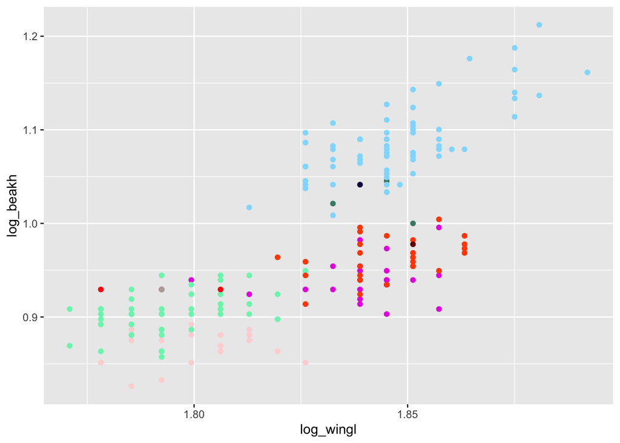

```r
taxon <- unique(morph$taxon)
colors_sp <- c(
    "#ff4d00",
    "#e636e1",
    "#78f4b9",
    "#90dcff",
    "#458b74",
    "#ffd6d6",
    "#ff0000",
    "#760300",
    "#b5aba9",
    "#150549")

col_dat <- tibble(taxon, colors_sp)

morph <- merge(morph, col_dat, by = "taxon")

ggplot(morph, aes(log_wingl, log_beakh, color = colors_sp)) +
    geom_point() +
    scale_color_identity()
```

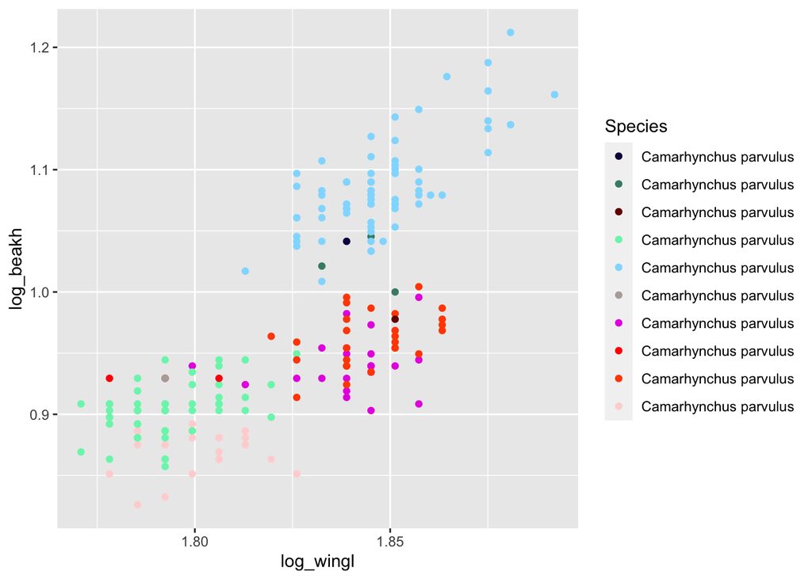

```r
#this works but where is our legend?
ggplot(morph, aes(log_wingl, log_beakh, color = colors_sp)) +
    geom_point() +
    scale_color_identity(guide = "legend",
                                             labels = c(as.factor(morph$taxon))) +
    labs(color = "Species")
```

Now let’s add plots together. Say we have one for females and one for males (we could also facet and customize, which we will do next. )

```r
10^min(morph$log_beakh)
```

```
## [1] 6.7
```

```r
10^max(morph$log_beakh)
```

```
## [1] 16.3
```

```r
range(morph$log_beakh)
```

```
## [1] 0.8260748 1.2121876
```

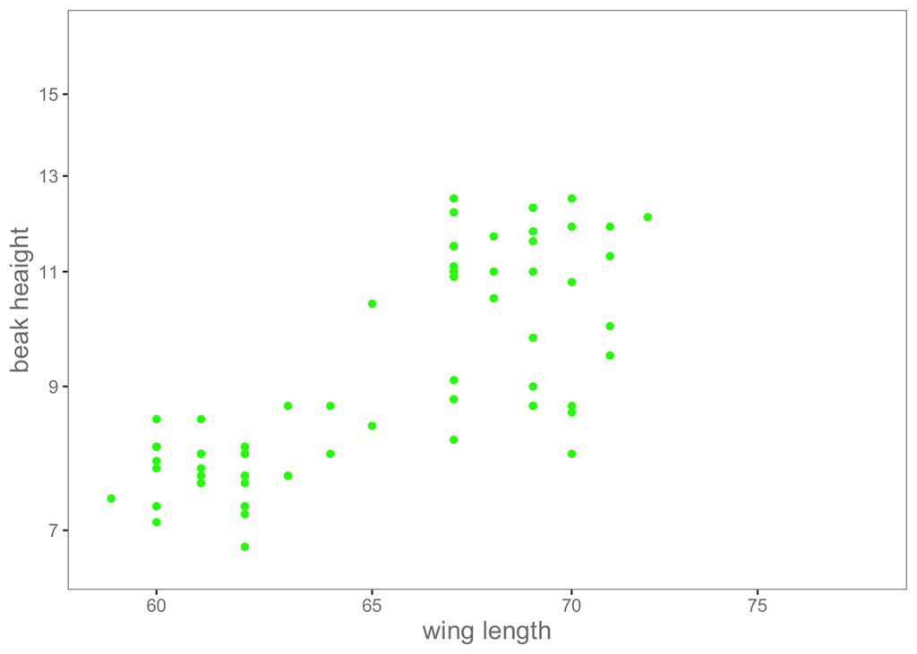

```r
morph_females <- morph %>%
    filter(sex == "F")

female_plot <-
    ggplot(morph_females, aes(log_wingl, log_beakh)) +
    geom_point(color = "green") +
    scale_x_continuous(
        name = "wing length", # change back to just wing length
        breaks = c(log10(60), log10(65), log10(70), log10(75)),
        labels = c(60, 65, 70, 75),
        limits= c(1.77, 1.893))  + # close to range of values
    scale_y_continuous(
        name = "beak heaight",
        breaks = c(log10(7), log10(9),log10(11),
                             log10(13), log10(15)),
        labels = c(7, 9, 11, 13, 15),
        limits= c(0.82, 1.22)) +
        theme(
            axis.title = element_text(size = 14, color = "grey50"),
            axis.text = element_text(size = 10, color = "grey50"),
            panel.grid.major = element_blank(),
            panel.grid.minor = element_blank(),
            panel.border = element_rect(color = "grey50", fill = NA),
            panel.background = element_rect(fill = NA))

female_plot
```

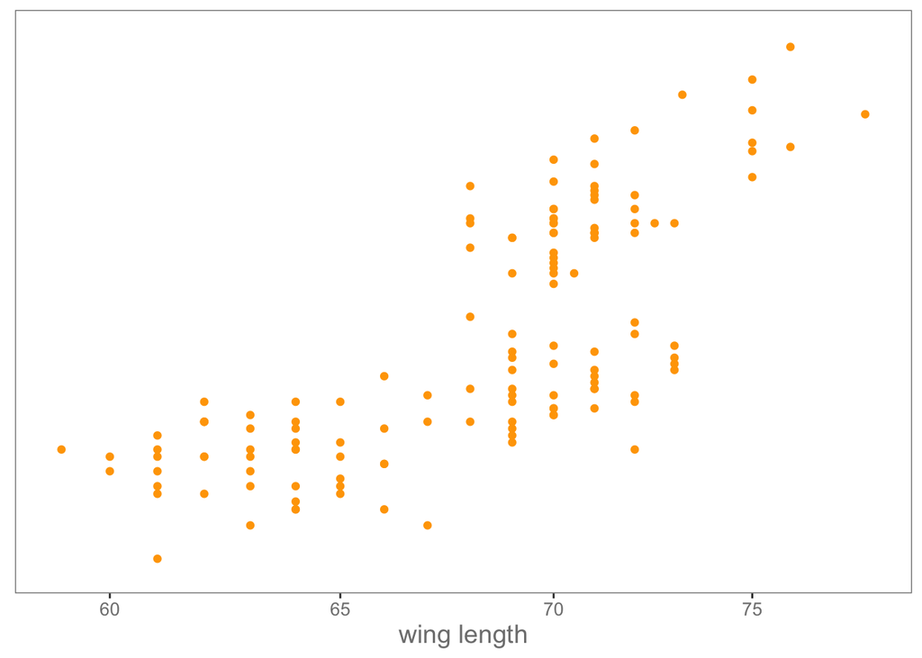

```r
# for the male plot, we don't need a y-axis since we are going to place these two plots side-by-side
morph_males <- morph %>%
    filter(sex == "M")

male_plot <-
    ggplot(morph_males, aes(log_wingl, log_beakh)) +
    geom_point(color = "orange") +
    scale_x_continuous(
        name = "wing length", # change back to just wing length
        breaks = c(log10(60), log10(65), log10(70), log10(75)),
        labels = c(60, 65, 70, 75),
        limits= c(1.77, 1.893))  + # close to range of values
    scale_y_continuous( # include this so plots on same scale
        name = "beak heaight",
        breaks = c(log10(7), log10(9),log10(11),
                             log10(13), log10(15)),
        labels = c(7, 9, 11, 13, 15),
        limits= c(0.82, 1.22)) +
        theme(
            axis.title.x = element_text(size = 14, color = "grey50"),
            axis.text.x = element_text(size = 10, color = "grey50"),
            axis.title.y = element_blank(),
            axis.text.y = element_blank(),
            axis.ticks.y = element_blank(),
            panel.grid.major = element_blank(),
            panel.grid.minor = element_blank(),
            panel.border = element_rect(color = "grey50", fill = NA),
            panel.background = element_rect(fill = NA))

male_plot
```

To put plots together, I use the patchwork library. I find it the least tedious. It’s documentation is here: https://patchwork.data-imaginist.com/. We have to specify the margin of each plot if we little to no space in between plots. We can also add a title.

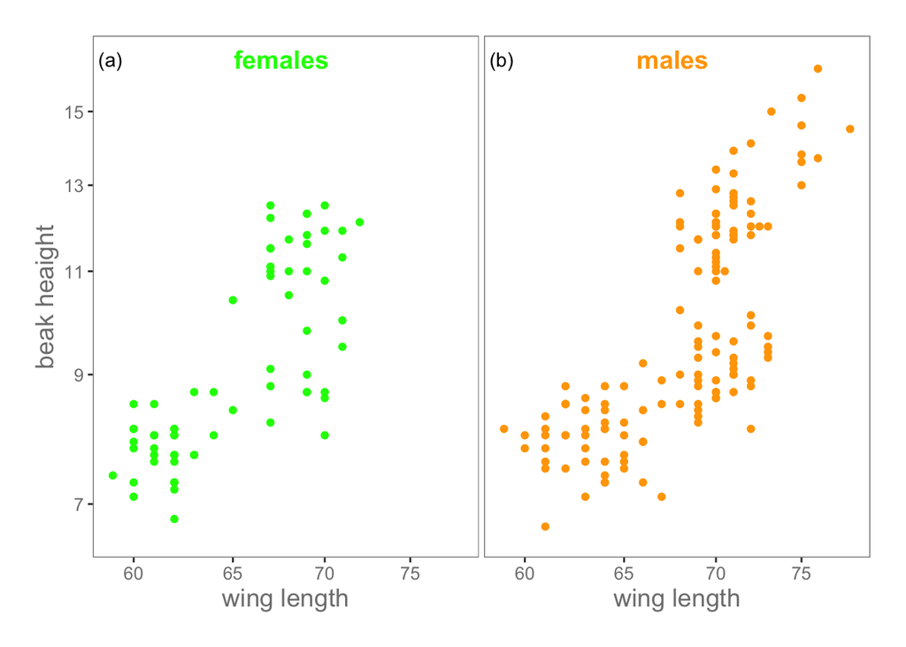

```r
plot1 <- female_plot +
    theme(plot.title = element_text(size = 14, hjust = 0.5,
                                                                    face = "bold", color = "green"),
                plot.margin = unit(c(0.2, 0, 0.2, 0.2), "in")) +
    annotate(geom = "text", label = "(a)", x = 1.77, y = 1.22) +
    annotate(geom = "text", label = "females", x = 1.83, y = 1.22,
                     color = "green", size = 5, fontface = "bold")


plot2 <- male_plot +
    theme(plot.title = element_text(size = 14, hjust = 0.5,
                                                                    face = "bold", color = "orange"),
                plot.margin = unit(c(0.2, 0.2, 0.2, 0), "in")) +
    annotate(geom = "text", label = "(b)", x = 1.77, y = 1.22) +
    annotate(geom = "text", label = "males", x = 1.83, y = 1.22,
                     color = "orange", size = 5, fontface = "bold")

plot_mem <- plot1 + plot2

ggsave(plot_mem,
             file = "plot_mem.png",
             width = 10,
             height = 5,
             units = "in")

plot_mem
```

Let’s pretend we faceted this plot and we want the same result.

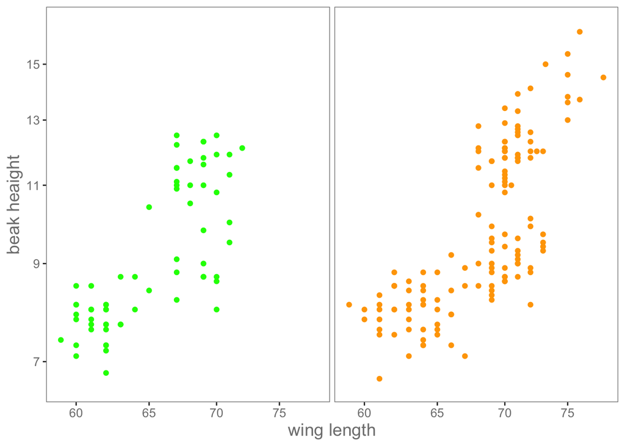

```r
mem_plot_facet <-
    ggplot(morph, aes(log_wingl, log_beakh, color = sex)) +
    geom_point() +
    facet_wrap(~ sex) +
    scale_color_manual(values = c("green", "orange")) +
    scale_x_continuous(
        name = "wing length", # change back to just wing length
        breaks = c(log10(60), log10(65), log10(70), log10(75)),
        labels = c(60, 65, 70, 75),
        limits= c(1.77, 1.893))  + # close to range of values
    scale_y_continuous( # include this so plots on same scale
        name = "beak heaight",
        breaks = c(log10(7), log10(9),log10(11),
                             log10(13), log10(15)),
        labels = c(7, 9, 11, 13, 15),
        limits= c(0.82, 1.22)) +
        theme(
            axis.title = element_text(size = 14, color = "grey50"),
            axis.text = element_text(size = 10, color = "grey50"),
            panel.grid.major = element_blank(),
            panel.grid.minor = element_blank(),
            panel.border = element_rect(color = "grey50", fill = NA),
            panel.background = element_rect(fill = NA),
            legend.position = "none",
            strip.background = element_blank(),
            strip.text = element_blank(),
            panel.spacing = unit(0.25, "lines"))

mem_plot_facet
```

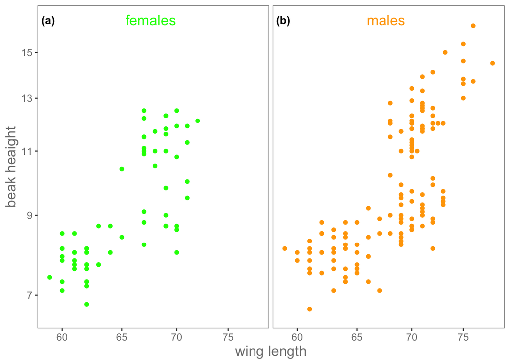

```r
# create a little dataset for text

female_text <- tibble(log_wingl = 1.83,
                                            log_beakh = 1.22,
                                            lab = "females",
                                            sex = factor("F", levels = c("F", "M")))

a_lab <- tibble(log_wingl = 1.77,
                                            log_beakh = 1.22,
                                            lab = "(a)",
                                            sex = factor("F", levels = c("F", "M")))

male_text <- tibble(log_wingl = 1.83,
                                        log_beakh = 1.22,
                                        lab = "males",
                                        sex = factor("M", levels = c("F", "M")))

b_lab <- tibble(log_wingl = 1.77,
                                log_beakh = 1.22,
                                lab = "(a)",
                                sex = factor("M", levels = c("F", "M")))


mem_plot_facet_title <- mem_plot_facet +
    geom_text(data = female_text, label = "females", size = 5) +
    geom_text(data = a_lab, label = "(a)", color = "black",
                        fontface = "bold") +
    geom_text(data = male_text, label = "males", size = 5) +
    geom_text(data = b_lab, label = "(b)", color = "black",
                        fontface = "bold")

ggsave(mem_plot_facet_title,
             file = "mem_plot_facet_title.png",
             width = 10,
             height = 5,
             units = "in")

mem_plot_facet_title
```

There is LOTS of other stuff to learn, but you have the basics. I usually look up modifications as I go or as my supervisor requests them ;).

Good luck!